# MNIST caso di studio

Alessandro Aere

22 maggio 2020

```r
library(tensorflow)
use_session_with_seed(28)
```

```
## Set session seed to 28 (disabled GPU)
```

```r
library(keras)
install_keras()
```

## Caricamento dei dati

```r
mnist <- dataset_mnist()
train_images <- mnist$train$x
train_labels <- mnist$train$y
test_images <- mnist$test$x
test_labels <- mnist$test$y
```

## Preparazione dei dati

Normalizzare i dati di input, riscalandoli tra 0 e 1.

```r
train_images <- train_images / 255
test_images <- test_images / 255
```

Trasformare la variabile risposta in variabile categoriale (usando il one-hot encoding).

```r
train_labels <- to_categorical(train_labels)
test_labels <- to_categorical(test_labels)
```

## Deep Neural Network

Specificare l’architettura della rete neurale:

- le immagini hanno una dimensione di $28\times28\times1$, ma la *feed-forward neural neutwork* prende in input solamente vettori unidimensionali; i pixel dell’immagine di input vengono quindi concatenati in un unico vettore di dimensione $784$;
- vengono utilizzati 3 strati latenti di dimensione $256$, $128$, $64$ rispettivamente;
- viene utilizzata la funzione *ReLU* come funzione di attivazione negli strati latenti, e la funzione *softmax* nello strato di output.

```r
model <- keras_model_sequential() %>%
layer_dense(units = 256, activation = "relu", input_shape = c(28 * 28)) %>%
layer_dense(units = 128, activation = "relu", input_shape = c(28 * 28)) %>%
layer_dense(units = 64, activation = "relu", input_shape = c(28 * 28)) %>%
layer_dense(units = 10, activation = "softmax")

model
```

```
## Model
## Model: "sequential"
## ________________________________________________________________________________
## Layer (type)                        Output Shape                    Param #
## ================================================================================
## dense (Dense)                       (None, 256)                     200960
## ________________________________________________________________________________
## dense_1 (Dense)                     (None, 128)                     32896
## ________________________________________________________________________________
## dense_2 (Dense)                     (None, 64)                      8256
## ________________________________________________________________________________
## dense_3 (Dense)                     (None, 10)                      650
## ================================================================================
## Total params: 242,762
## Trainable params: 242,762
## Non-trainable params: 0
## ________________________________________________________________________________
```

Compilare il modello:

- l’ottimizzatore utilizzato è `adam`, con un *learning rate* pari a $0.001$;
- viene utilizzata la *cross-entropia* come funzione di perdita, e l’*accuratezza* come metrica di valutazione.

```r
model %>% compile(
  optimizer = optimizer_adam(lr = 0.001),
  loss = "categorical_crossentropy",
  metrics = c("accuracy")
)
```

Training della rete neurale.

```r
history <- model %>% fit(
  x = array_reshape(train_images, c(60000, 28 * 28)),
  y = train_labels,
  epochs = 10,
  batch_size = 32,
  validation_split = 0.2,
  verbose = 1
)
```

In seguito viene rappresentato il grafico della funzione di perdita e dell’accuratezza in funzione del numero di epoche.

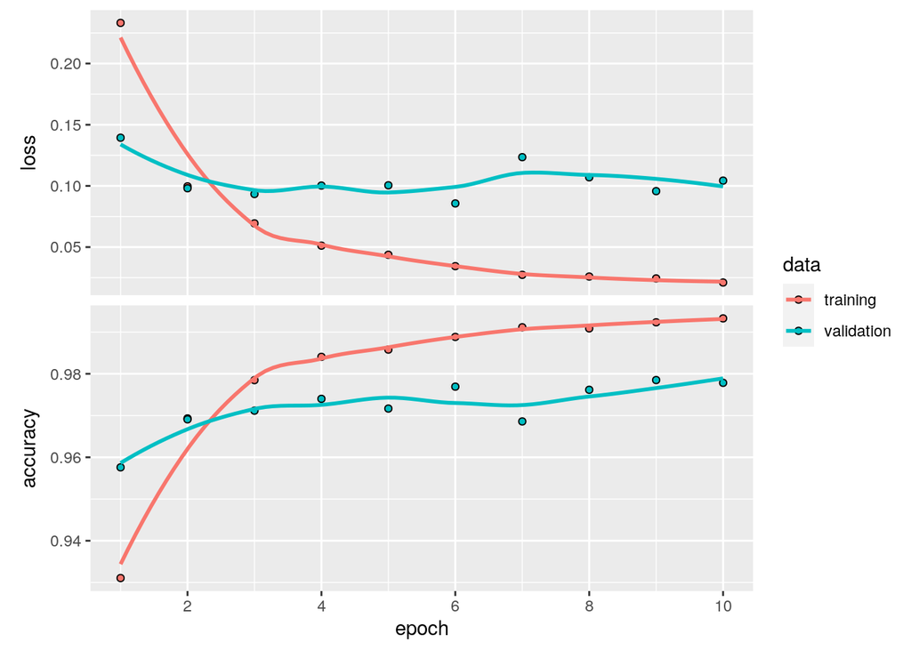

```r
plot(history)
```

Valutazione del modello sui dati di test.

```r
results <- model %>% evaluate(
  x = array_reshape(test_images, c(10000, 28 * 28)),
  y = test_labels,
  verbose = 0
)

print(paste("Loss on test data:", results["loss"]))
```

```
## [1] "Loss on test data: 0.0800118893384933"
```

```r
print(paste("Accuracy on test data:", results["accuracy"]))
```

```
## [1] "Accuracy on test data: 0.981299996376038"
```

# Convolutional neural network

Specificare l’architettura della rete neurale:

- nella parte convoluzionale viene utilizzata una sequenza di layer di tipo `conv`->`pool`->`conv`->`pool`->`conv`;
- nella parte *fully-connected* viene utilizzato uno strato latente di dimensione $64$;
- viene utilizzata la funzione *ReLU* come funzione di attivazione negli strati latenti, e la funzione *softmax* nello strato di output.

```r
model <- keras_model_sequential() %>%
layer_conv_2d(filters = 32, kernel_size = c(3, 3), activation = "relu", input_shape = c(28, 28, 1)) %>%
layer_max_pooling_2d(pool_size = c(2, 2)) %>%
layer_conv_2d(filters = 64, kernel_size = c(3, 3), activation = "relu") %>%
layer_max_pooling_2d(pool_size = c(2, 2)) %>%
layer_conv_2d(filters = 64, kernel_size = c(3, 3), activation = "relu") %>%
layer_flatten() %>%
layer_dense(units = 64, activation = "relu") %>%
layer_dense(units = 10, activation = "softmax")

model
```

```
## Model
## Model: "sequential_1"
## ________________________________________________________________________________
## Layer (type)                        Output Shape                    Param #
## ================================================================================
## conv2d (Conv2D)                     (None, 26, 26, 32)              320
## ________________________________________________________________________________
## max_pooling2d (MaxPooling2D)        (None, 13, 13, 32)              0
## ________________________________________________________________________________
## conv2d_1 (Conv2D)                   (None, 11, 11, 64)              18496
## ________________________________________________________________________________
## max_pooling2d_1 (MaxPooling2D)      (None, 5, 5, 64)                0
## ________________________________________________________________________________
## conv2d_2 (Conv2D)                   (None, 3, 3, 64)                36928
## ________________________________________________________________________________
## flatten (Flatten)                   (None, 576)                     0
## ________________________________________________________________________________
## dense_4 (Dense)                     (None, 64)                      36928
## ________________________________________________________________________________
## dense_5 (Dense)                     (None, 10)                      650
## ================================================================================
## Total params: 93,322
## Trainable params: 93,322
## Non-trainable params: 0
## ________________________________________________________________________________
```

Compilare il modello:

- l’ottimizzatore utilizzato è `adam`, con un *learning rate* pari a $0.001$;
- viene utilizzata la *cross-entropia* come funzione di perdita, e l’*accuratezza* come metrica di valutazione.

```r
model %>% compile(
  optimizer = optimizer_adam(lr = 0.001),
  loss = "categorical_crossentropy",
  metrics = c("accuracy")
)
```

Training della rete neurale.

```r
history <- model %>% fit(
  x = array_reshape(train_images, c(60000, 28, 28, 1)),
  y = train_labels,
  epochs = 10,
  batch_size = 32,
  validation_split = 0.2,
  verbose = 1
)
```

In seguito viene rappresentato il grafico della funzione di perdita e dell’accuratezza in funzione del numero di epoche.

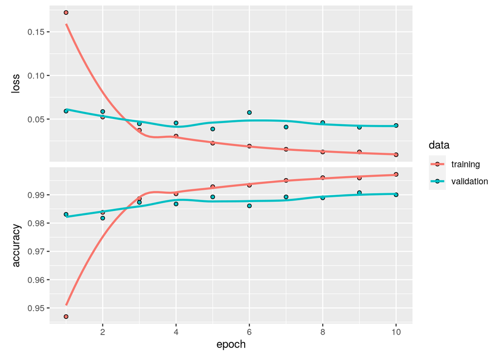

```r
plot(history)
```

Valutazione del modello sui dati di test.

```r
results <- model %>% evaluate(
  x = array_reshape(test_images, c(10000, 28, 28, 1)),
  y = test_labels,
  verbose = 0
)

print(paste("Loss on test data:", results["loss"]))
```

```
## [1] "Loss on test data: 0.0369316786527634"
```

```r
print(paste("Accuracy on test data:", results["accuracy"]))
```

```
## [1] "Accuracy on test data: 0.98989999294281"
```